# NLP · Entity Ruler para detectar disruptores en etiquetas OCR

El objetivo de este notebook es **construir** y **validar** un detector de ingredientes (INCI) asociados a disruptores endocrinos a partir de textos OCR de etiquetas, usando **spaCy `EntityRuler`**. El modelo se contruye a partir de `en_core_web_md`, desactivando **ner** y añadiendo un **EntityRuler** con validación y sobrescritura de entidades para controlar la calidad de los patrones.

### Entradas de datos:

- Partimos de un dataframe disruptores_finales que cuenta con el listado de sustancias con su nombre INCI. En este dataframe hay un campo donde se incluye el texto de etiquetas reales de 63 sustancias, para realizar un análisis de texto con el modelo nlp que se va a contruir.
  - Las variables importantes de este dataframe para la construcción de patrones son: "nombre_etiqueta", "CAS Number", "EC Number".
  - Para el análisis del texto de las 63 sustancias con el modelo nlp tenemos la variable "texto".
  - Con este dataframe se crea un alias por sustancia, pues hay algunas sustancias con mismo "CAS Number" y "EC Number" pero varios "nombres_etiqueta" porque pueden llamarse de forma distinta. Por ese motivo, tanto para la creación de patrones como para la evaluación hay que hacer groupby por CAS y EC number.
- Por otro lado, tenemos un dataframe con textos de 170 imagenes analizadas en OCR de las mismas 63 sustancias anteriores.
  - Este dataframe solo contiene 2 variables: "imagen_nombre" y "texto_ocr".
  - Este dataframe se une con el anterior para poder hacer el anális de texto.

### Normalización:

Para robustecer el reconocimiento, se aplican utilidades propias que **no dependen del pipeline NLP**, porque spacy al tokenizar quita guinones, comas y números que son parte del token que necesitamos como sustancia.

- Para la creación de patrones realizamos una normalización sencilla para conservar la forma con **normalize_for_pattern**: minúsculas, quita espacios al inicio y final y divide por espacios y guiones.
- Antes de introducir el **texto** y el **texto_ocr** al nlp, sometemos estas a un normalización para facilitar el trabajo a spacy y que detecte lo mejor posibles las entidades (disruptores):
  - normalización “legible” **(normalize)** que esta compuesta por:
    - **(unify_dashes):** unificación de guiones raros
    - **(get_tokens):** tokenización por **regex** que preserva alfanuméricos, comas y guiones.
    - **(to_lowercase)** y **(no_symbols):** minúsculas y limpieza de símbolos.

### Construcción de patrones:

A partir de cada alias se generan **tres familias de patrones** para cubrir las variaciones comunes en etiquetas:

1. **Multi-token exacto** (insensible a mayúsculas):
   - A partir del alias tokenizado en minúsculas se construye una secuencia como **[{ "LOWER": t1 }, { "LOWER": t2 }, …]**.
   - Por ejemplo para el alias **butylated hydroxy toluene** se crea un patron: `{"LOWER": {butylated} , { "LOWER":hydroxy} , { "LOWER":toluene} }`
   - Solo casa cuando esos mismos tokens aparecen contiguos en el texto (independiente de mayúsculas), p. ej.: butylated hydroxy toluene.
2. **Regex de un solo token** (compacto/guionizado dentro del token)
   - Si el alias tiene ≥2 tokens, se genera una regex **^t1-?t2-?…-?tn$** para el patrón **{"LOWER": {"REGEX": regex}}**
   - Por ejemplo para el alias **butylated hydroxy toluene** se crea un patron: `{"LOWER": {"REGEX":^butylated-?hydroxy-?toluene$}}`
   - De esta forma en el caso de que Spacy cuando analice el texto dicho alias llegue como un **único** token se cubran las opciones: butylatedhydroxytoluene o butylated-hydroxy-toluene
3. **multi-token con guion opcional ENTRE tokens**
   - Si el alias tiene ≥2 tokens, construimos una secuencia que intercala un guion como token opcional entre cada palabra: **[{ "LOWER": t1 }, { "ORTH": "-", "OP": "?" }, { "LOWER": t2 }, …, { "ORTH": "-", "OP": "?" }, { "LOWER": tn }]**.
   - Por ejemplo: `[{"LOWER": "butylated"}, {"ORTH": "-", "OP": "?"}, {"LOWER": "hydroxy"}, {"ORTH": "-", "OP": "?"}, {"LOWER": "toluene"}]`
   - Este patrón casa tanto cuando las palabras van separadas por espacios como cuando aparecen con guiones que spaCy tokeniza como tokens. Cubre por ejemplo: butylated hydroxy toluene (ya lo cubre la 1º opción), butylated - hydroxy - toluene y el habitual butylated-hydroxy-toluene (lo cubre la 2º opción).

### Evaluación (Texto → Entity Ruler + métricas rápidas).:

Con los patrones creados se evaluan los textos de ambos dataframes, el objetivo es saber cuanta presición tiene, pues tanto los textos que se van a evaluar tienen las siguientes características:

- En la página de Incidecode hemos buscado una muestra de 63 sustancias disruptoras, dicha página te dice los productos que contienen el ingrediente buscado.
- Cuando accedes a los productos con el ingrediente disruptor te muestra el texto de la etiqueta, hemos copiado dicho texto y realizado capturas de pantalla para tener una imagen que analizar.
- Hay 63 ingredientes a las que se le ha añadido texto de las etiquetas, dichos textos contienen **al menos** el disruptor que aparece en el la variable nombre_etiqueta. Es decir, el modelo tendría que hacer match con las 63 sustancias porque todas son disruptores.
- De las mismas 63 sustancias se han añadido las imagenes de sus etiquetas, adicionalmente se han añadido de 1 a 2 imagenes más de la misma sustancia en algunos casos, obteniendo un total de 170 imagenes. El modelo tambien tendría que hacer match con las 170 imagenes porque todas contienen disrutores, al menos el que coincide con la variable nombre_etiqueta.
- Las 170 imagenes se evaluan por OCR para obtener la variable texto_ocr que es la que se va a analizar.

Posteriomente, se aplica el pipeline sobre los textos y los textos OCR para extraer las **entidades detectadas** y los **ids detectados** que guardamos en las variables `detected_entities` y `detected_ids`.

Para la evaluación se utilizan estas variables con las de los dataframes originales para hacer match por ID si se cumple la variable creada `acierto == 1` y haciendo la media obtenemos el porcentaje de acierto.

### Visualización de los ingredientes evaluados

Para enriquecer la información obtenida hemos añadido nuevamente las variables:

- "Fuente_original"
- "Anexo_cosIng"
- 'Health_effects'

Hemos sacado las gráficas de los resultados para ver como se distribuyen estas variables, pues hay que tener en cuenta que si:

1. La Fuente original es Edlist_2, dicho ingrediente esta aún en evaluación , es decir, **NO es un disruptor confirmado**
2. La Fuente original es Edlist_3, dicho ingrediente esta confirmado como disruptor solo por algún pais miembro pero **NO por la comisión de la UE**
3. El Anexo cosing es el Anexo 2, dicho ingrediente está prohibido por la UE para incluirlo en productos cosméticos.
4. A modo informativo, si Health_effects ==1, dicho ingrediente tiene efectos para la salud, en caso contrario puede tenerlos para el medio ambiente o para ninguno.

## 1. Importación de librerias y funciones

### 1.1. Importación de librerias

```python
import json
import spacy
import pandas as pd
from spacy.pipeline import EntityRuler
import re
from plotnine import *
from plotnine.positions import position_stack, position_fill
import sys
from rapidfuzz import fuzz
from pathlib import Path
```

### 1.2. Importación de Funciones

Para poder importar las funciones tenemos que hacer visible la carpeta de importación porque está en otro nivel

```python
# Hace visible la carpeta 'src' desde cualquier notebook

def add_project_root(marker="src"):
    """Sube directorios desde el cwd hasta encontrar uno que contenga 'src' y lo añade a sys.path."""
    here = Path.cwd()
    for parent in (here, *here.parents):
        if (parent / marker).is_dir():
            p = str(parent)
            if p not in sys.path:
                sys.path.insert(0, p)
            return parent
    raise RuntimeError("No se encontró la raíz del proyecto (carpeta con 'src').")

PROJECT_ROOT = add_project_root()
print("✓ Proyecto:", PROJECT_ROOT)

#  Recarga automáticamente si edito modulos del archivo de funciones
%load_ext autoreload
%autoreload 2
```

```
✓ Proyecto: b:\IMF\TFM\tfm-disruptors
```

**Funciones de normalización y creación de patrones**

```python
from src.nlp.nlp_functions import normalize, normalize_for_pattern, build_patterns_from_df

# normalize depende de: unify_dashes, get_tokens, to_lowercase, no_symbols
# build_patterns_from_df depende de: make_ent_id, regex_compact_phrase, sequence_with_optional_dashes_between_tokens y normalize_for_pattern
```

**Funciones para evaluación de algoritmo y visualización**

```python
from src.nlp.nlp_functions import match_row, facet_bar_pct
```

## 2. Carga y lectura de datos

```python
# Rutas
ruta_disruptores = "../../data/processed/notebooks/disruptores_final.parquet"
ruta_jsonl       = "../../data/processed/notebooks/ocr_output.jsonl"
```

### 2.1 Archivo disruptores final

De este archivo vamos a:

1. Crear un dataframe para el analizar texto en nlp
2. Crear un dataframe para el analisis de imagen en nlp

```python
# leemos los datos de la lista de disruptores_final
disruptores_final = pd.read_parquet(ruta_disruptores).copy()
disruptores_final.info()
```

```
<class 'pandas.core.frame.DataFrame'>
RangeIndex: 164 entries, 0 to 163
Data columns (total 15 columns):
 #   Column                Non-Null Count  Dtype
---  ------                --------------  -----
 0   Name_Edlist_Echa      164 non-null    object
 1   Name_Chemical_Cosing  52 non-null     object
 2   Fuente_original       164 non-null    object
 3   Anexo_cosIng          164 non-null    object
 4   Appears_on_lists      130 non-null    object
 5   Health_effects        164 non-null    int64
 6   CAS Number            164 non-null    string
 7   EC Number             164 non-null    string
 8   nombre_etiqueta       164 non-null    object
 9   uso                   151 non-null    object
 10  productos_cosmeticos  164 non-null    int64
 11  imagen_nombre         63 non-null     object
 12  imagen_cantidad       162 non-null    float64
 13  texto                 63 non-null     object
 14  fuente_manual         112 non-null    object
dtypes: float64(1), int64(2), object(10), string(2)
memory usage: 19.3+ KB
```

```python
# Creamos df para el análisis del texto en nlp
df_text = (disruptores_final[[ "CAS Number", "EC Number", "nombre_etiqueta","texto", "imagen_nombre"]].copy())
df_text = df_text[df_text["texto"].notna()]
df_text = df_text[df_text["texto"].astype(str).str.strip() != ""]
```

```python
df_text.info()
```

```
<class 'pandas.core.frame.DataFrame'>
Index: 63 entries, 0 to 162
Data columns (total 5 columns):
 #   Column           Non-Null Count  Dtype
---  ------           --------------  -----
 0   CAS Number       63 non-null     string
 1   EC Number        63 non-null     string
 2   nombre_etiqueta  63 non-null     object
 3   texto            63 non-null     object
 4   imagen_nombre    63 non-null     object
dtypes: object(3), string(2)
memory usage: 3.0+ KB
```

```python
# Creamos df para el análisis de imágenes en nlp
df_imgs_map = disruptores_final[["CAS Number","EC Number","nombre_etiqueta","imagen_nombre"]]
df_imgs_map = df_imgs_map[df_imgs_map["imagen_nombre"].notna()]
```

```python
df_imgs_map.head()
```

|  | CAS Number | EC Number | nombre_etiqueta | imagen_nombre |
| --- | --- | --- | --- | --- |
| 0 | 101-20-2 | 202-924-1 | triclocarban | etiqueta_001.jpg/etiqueta_002.jpg/etiqueta_003... |
| 1 | 106-24-1 | 203-377-1 | geraniol | etiqueta_004.jpg/etiqueta_005.jpg/etiqueta_006... |
| 2 | 108-46-3 | 203-585-2 | resorcinol | etiqueta_007.jpg/etiqueta_008.jpg/etiqueta_009... |
| 3 | 119-36-8 | 204-317-7 | methyl salicylate | etiqueta_010.jpg/etiqueta_011.jpg/etiqueta_012... |
| 4 | 1222-05-5 | 214-946-9 | hexamethylindanopyran | etiqueta_013.jpg/etiqueta_014.jpg/etiqueta_015... |

Vemos que la variable imagen_nombre contiene varios nombres para un mismo registro.

Para nuestro **análisis de imagen SI es importante** tener los nombres separados por fila, por ese motivo hay que hacer explode

```python
# Explode por '/' en la variable imagen_nombre
df_imgs_map["imagen"] = df_imgs_map["imagen_nombre"].str.split("/")
df_imgs_map= df_imgs_map.explode("imagen")
# nos aseguramos de que la columna imagen tenga el formato correcto
df_imgs_map["imagen"] = df_imgs_map["imagen"].astype(str).str.strip()
```

```python
# eliminamos la columna original
df_imgs_map = df_imgs_map.drop(columns=["imagen_nombre"])

# renombramos la columna de nombre de imagen
df_imgs_map = df_imgs_map.rename(columns={"imagen": "imagen_nombre"}).reset_index(drop=True)
```

```python
# Comprobamos que se realizó correctamente
df_imgs_map.head(3)
```

|  | CAS Number | EC Number | nombre_etiqueta | imagen_nombre |
| --- | --- | --- | --- | --- |
| 0 | 101-20-2 | 202-924-1 | triclocarban | etiqueta_001.jpg |
| 1 | 101-20-2 | 202-924-1 | triclocarban | etiqueta_002.jpg |
| 2 | 101-20-2 | 202-924-1 | triclocarban | etiqueta_003.jpg |

```python
df_imgs_map.info()
```

```
<class 'pandas.core.frame.DataFrame'>
RangeIndex: 170 entries, 0 to 169
Data columns (total 4 columns):
 #   Column           Non-Null Count  Dtype
---  ------           --------------  -----
 0   CAS Number       170 non-null    string
 1   EC Number        170 non-null    string
 2   nombre_etiqueta  170 non-null    object
 3   imagen_nombre    170 non-null    object
dtypes: object(2), string(2)
memory usage: 5.4+ KB
```

Como hemos comentado en el enunciado, hay 63 nombres de etiqueta que tienen el texto del ingrediente y a esas 63 sustancias se les ha incorporado su imagen y otras adicionales, de manera que el total son 170.

```python
df_imgs_map["nombre_etiqueta"].nunique()
```

```
63
```

### 2.2 Archivo ocr_output

De este archivo vamos a obtener el dataframe con la lectura de imagenes en ocr y lo uniremos con el creado en el apartado anterior para que tenga todos los datos necesarios

```python
# Cargamos OCR JSONL
rows = []
with open(ruta_jsonl, encoding="utf-8") as ocr_file:
    for line in ocr_file:
        line = line.strip()
        if not line:
            continue
        item = json.loads(line)
        img = item.get("image")
        txt = item.get("text", "")
        if img is None:
            continue
        img = str(img).strip()
        if not img.endswith(".jpg"):
            img += ".jpg"
        rows.append({"imagen_nombre": img, "texto_ocr": txt})


ocr_df = pd.DataFrame(rows)
ocr_df.info()
```

```
<class 'pandas.core.frame.DataFrame'>
RangeIndex: 170 entries, 0 to 169
Data columns (total 2 columns):
 #   Column         Non-Null Count  Dtype
---  ------         --------------  -----
 0   imagen_nombre  170 non-null    object
 1   texto_ocr      170 non-null    object
dtypes: object(2)
memory usage: 2.8+ KB
```

```python
# Unimos ambos df por imagen para saber el objetivo (CAS/EC y nombre esperado)
df_eval_img = ocr_df.merge(
    df_imgs_map[["imagen_nombre","nombre_etiqueta","CAS Number","EC Number"]],
    on="imagen_nombre", how="left"
)
df_eval_img.info()
```

```
<class 'pandas.core.frame.DataFrame'>
RangeIndex: 170 entries, 0 to 169
Data columns (total 5 columns):
 #   Column           Non-Null Count  Dtype
---  ------           --------------  -----
 0   imagen_nombre    170 non-null    object
 1   texto_ocr        170 non-null    object
 2   nombre_etiqueta  170 non-null    object
 3   CAS Number       170 non-null    string
 4   EC Number        170 non-null    string
dtypes: object(3), string(2)
memory usage: 6.8+ KB
```

## 3. Modelo Entity Ruler

```python
# Cargamos modelo
nlp = spacy.load("en_core_web_md", disable=["ner"])
# Añadimos el EntityRuler al pipeline. Sobreescribo las entidades existentes
# tambien añado validación para detectar patrones mal formados
ruler = nlp.add_pipe("entity_ruler", config={"overwrite_ents": True, "validate": True}, before="ner")
```

```python
# Generamos la lista de patrones
patrones = build_patterns_from_df(disruptores_final)
ruler.add_patterns(patrones)
```

Mostramos cómo para un elemento se han creado las 3 familias de patrones.

```python
list(i for i in patrones if i['id']  == 'CAS:85-68-7|EC:201-622-7')
```

```
[{'label': 'DISRUPTOR',
  'pattern': [{'LOWER': 'butyl'}, {'LOWER': 'benzyl'}, {'LOWER': 'phthalate'}],
  'id': 'CAS:85-68-7|EC:201-622-7'},
 {'label': 'DISRUPTOR',
  'pattern': [{'LOWER': {'REGEX': '^butyl-?benzyl-?phthalate$'}}],
  'id': 'CAS:85-68-7|EC:201-622-7'},
 {'label': 'DISRUPTOR',
  'pattern': [{'LOWER': 'butyl'},
   {'ORTH': '-', 'OP': '?'},
   {'LOWER': 'benzyl'},
   {'ORTH': '-', 'OP': '?'},
   {'LOWER': 'phthalate'}],
  'id': 'CAS:85-68-7|EC:201-622-7'}]
```

**Guardamos los patrones creados para usarlo en otros archivos**

```python
ruler.to_disk("./entity_ruler_patterns.jsonl")
```

**Consultamos la información de los que disponemos antes de hacer analisis de texto**

Aunque el dataframe de disruptores_finales tenga 164 registros, no quiere decir que sean 164 sustancias, sino que las sustancias tienen más de un alias, por ese motivo, vamos a mostras los valores únicos de las variables en cuestión

```python
n_alias = disruptores_final["nombre_etiqueta"].nunique()
n_cas = disruptores_final["CAS Number"].nunique()
n_ec = disruptores_final["EC Number"].nunique()
n_name_edlist = disruptores_final["Name_Edlist_Echa"].nunique()
n_texto = disruptores_final["texto"].nunique()
n_texto_imagen = df_eval_img["texto_ocr"].nunique()

print(f"Alias totales (filas de nombre_etiqueta): {n_alias}")
print(f"CAS totales (registros CAS Number único): {n_cas}")
print(f"EC totales (registros EC Number único): {n_ec}")
print(f"Disruptores totales (registros Name_Edlist_Echa único): {n_name_edlist}")
print(f"Textos totales (registros texto único): {n_texto}")
print(f"Textos ocr totales (registros texto_imagen único): {n_texto_imagen}")
print(f"Patrones cargados en EntityRuler: {len(patrones)}")
```

```
Alias totales (filas de nombre_etiqueta): 164
CAS totales (registros CAS Number único): 79
EC totales (registros EC Number único): 78
Disruptores totales (registros Name_Edlist_Echa único): 77
Textos totales (registros texto único): 63
Textos ocr totales (registros texto_imagen único): 170
Patrones cargados en EntityRuler: 408
```

Hay menos **Name_Edlist_Echa** que **CAS y EC** porque hay ingredientes que tiene más de un CAS y EC por ejemplo:

```python
disruptores_final[disruptores_final["Name_Edlist_Echa"] == "Cyclomethicone"]
```

|  | Name_Edlist_Echa | Name_Chemical_Cosing | Fuente_original | Anexo_cosIng | Appears_on_lists | Health_effects | CAS Number | EC Number | nombre_etiqueta | uso | productos_cosmeticos | imagen_nombre | imagen_cantidad | texto | fuente_manual |
| --- | --- | --- | --- | --- | --- | --- | --- | --- | --- | --- | --- | --- | --- | --- | --- |
| 111 | Cyclomethicone | None | EDlist_2 (evaluando) | Sin información | List II | 1 | 540-97-6 | 208-762-8 | CYCLOHEXASILOXANE | ACONDICIONADOR DE LA PIEL - EMOLIENTE\nACONDIC... | 1 | etiqueta_123.jpg/etiqueta_124.jpg | 2.0 | Cyclohexasiloxane, Water, Titanium Dioxide, Di... | Cosing |
| 112 | Cyclomethicone | None | EDlist_2 (evaluando) | Sin información | List II | 1 | 540-97-6 | 208-762-8 | dodecamethylcyclohexasiloxane | ACONDICIONADOR DE LA PIEL - EMOLIENTE\nACONDIC... | 1 | None | 0.0 | None | Cosing |
| 113 | Cyclomethicone | None | EDlist_2 (evaluando) | Sin información | List II | 1 | 540-97-6 | 208-762-8 | Cyclomethicone 6 | ACONDICIONADOR DE LA PIEL - EMOLIENTE\nACONDIC... | 1 | None | 0.0 | None | Cosing |
| 127 | Cyclomethicone | None | EDlist_2 (evaluando) | Sin información | List II | 1 | 69430-24-6 | 209-136-7 | CYCLOMETHICONE | ACONDICIONADOR DE LA PIEL - EMOLIENTE\nACONDIC... | 1 | etiqueta_084.jpg/etiqueta_085.jpg/etiqueta_086... | 3.0 | Ingredients overview\nCyclomethicone, Titanium... | Cosing |

## 4. Texto → Entity Ruler + evaluación

Con este anális lo que se pretende es aislar el funcionamiento del modelo nlp con el ocr.

Para ello, hemos creado la variable `texto` y en una muestra de 63 sustancias se les ha añadido el texto de la etiqueta que contiene dicho disruptor.

**Obejtivo:** Como todos los registros contienen en la variable `texto` el disruptor que aparece en la variable target `nombre_etiqueta` -> nuestro modelo debería **encontrar el 100%** de las sustancias de la variable **target**.

**Importante:**

1. Los patrones integrados en el nlp se han creado a partir de las variables: `nombre_etiqueta` y `CAS Number` y `EC Number` actuando estos como ID
2. La variable `texto` puede contener más de un disruptor, en caso de que se encuentren más de uno se tendrán en cuenta
3. Como se pueden encontrar más de un disruptor, y puede que se detecten otros que no se encuentren en la variable `nombre_etiqueta` asociada, contamos como **"acierto"** solo si coincide con la el registro que es.
4. La función match_row empareja las entidades detectadas por IDs, recordemos que los patrones creados tienen tambien el ID y cuando se pasa el texto por el nlp, obtenemos de spacy `ents_text` y `ents_ids` de esta manera no solo tenemos la entidad que ha detectado el modelo sino tambien su id con el que realizaremos la comparativa.

```python
df_text.info()
```

```
<class 'pandas.core.frame.DataFrame'>
Index: 63 entries, 0 to 162
Data columns (total 5 columns):
 #   Column           Non-Null Count  Dtype
---  ------           --------------  -----
 0   CAS Number       63 non-null     string
 1   EC Number        63 non-null     string
 2   nombre_etiqueta  63 non-null     object
 3   texto            63 non-null     object
 4   imagen_nombre    63 non-null     object
dtypes: object(3), string(2)
memory usage: 3.0+ KB
```

```python
# Creamos df con indices limpios
df_eval = df_text.copy().reset_index(drop=True)

# Como ya no se trata de una muestra de texto, sino de de varios textos a procesar hay que crear una lista de ellos.
texts = []
for t in df_eval["texto"]:
    texts.append(normalize(t))

# Procesamos texto con nlp.pipe que es más eficiente para varios textos
docs = list(nlp.pipe(texts, batch_size=64))
```

```python
# Extraemos entidades detectadas (solo DISRUPTOR)
# Como temos una lista de documentos y no solo un documento, guardamos en una lista las entidades de cada documento
det_texts = []
det_ids   = []
for doc in docs:
    ents_text = []
    ents_ids  = []
    for ent in doc.ents:
        if ent.label_ == "DISRUPTOR":
            ents_text.append(ent.text)
            ents_ids.append(ent.ent_id_ or "")
    det_texts.append(ents_text)
    det_ids.append(ents_ids)

# creamos columnas
df_eval["detected_entities"]= det_texts
df_eval["detected_ids"]= det_ids
```

```python
df_eval.tail(2)
```

|  | CAS Number | EC Number | nombre_etiqueta | texto | imagen_nombre | detected_entities | detected_ids |
| --- | --- | --- | --- | --- | --- | --- | --- |
| 61 | 9002-93-1 |  | OCTOXYNOL-13 | Ingredients overview\nWater/Eau (Aqua), Hamam... | etiqueta_165.jpg/etiqueta_166.jpg/etiqueta_167... | [octoxynol-13, methylparaben, propylparaben] | [CAS:9002-93-1, CAS:99-76-3\|EC:202-785-7, CAS:... |
| 62 | 99-76-3 | 202-785-7 | methylparaben | Ingredients overview\nMethylparaben, Beeswax, ... | etiqueta_168.jpg/etiqueta_169.jpg/etiqueta_170... | [methylparaben, propylparaben] | [CAS:99-76-3\|EC:202-785-7, CAS:94-26-8\|EC:202-... |

```python
# Evaluación del modelo
hit = [] # acierto
types = [] # tipos de coincidencia
match_str  = [] # texto de coincidencia
# iteramos cada fila para hacer match
for idx, row in df_eval.iterrows():
    h, t, m = match_row(row)
    hit.append(h); types.append(t); match_str.append(m)

# Creamos columnas
df_eval["acierto"]    = hit
df_eval["match_type"] = types
df_eval["match_str"]  = match_str
df_eval["n_detected"] = df_eval["detected_entities"].apply(len)
```

```python
df_eval.head(2)
```

|  | CAS Number | EC Number | nombre_etiqueta | texto | imagen_nombre | detected_entities | detected_ids | acierto | match_type | match_str | n_detected |
| --- | --- | --- | --- | --- | --- | --- | --- | --- | --- | --- | --- |
| 0 | 101-20-2 | 202-924-1 | triclocarban | Ingredients overview\nSodium Palmate, Sodium P... | etiqueta_001.jpg/etiqueta_002.jpg/etiqueta_003... | [triclocarban, bht] | [CAS:101-20-2\|EC:202-924-1, CAS:128-37-0\|EC:20... | 1 | id | triclocarban | 2 |
| 1 | 106-24-1 | 203-377-1 | geraniol | Aqua, Rosa Damascena Flower Water, Geraniol, C... | etiqueta_004.jpg/etiqueta_005.jpg/etiqueta_006... | [geraniol] | [CAS:106-24-1\|EC:203-377-1] | 1 | id | geraniol | 1 |

```python
df_eval.describe()
```

|  | acierto | n_detected |
| --- | --- | --- |
| count | 63.0 | 63.000000 |
| mean | 1.0 | 2.031746 |
| std | 0.0 | 1.121178 |
| min | 1.0 | 1.000000 |
| 25% | 1.0 | 1.000000 |
| 50% | 1.0 | 2.000000 |
| 75% | 1.0 | 3.000000 |
| max | 1.0 | 6.000000 |

Vemos en los estadísticos que se ha acertado el 100% y que la media de disruptores encontrados es de 2, teniendo en cuenta que el objetivo era encontrar 1 por ingrediente, el hecho de que la media sea 2 indica que hay ingredientes que tienen más de 1 disruptor.

Igualemente vamos a sacar la información:

```python
porcentaje_id        = 100 * (df_eval["match_type"] == "id").mean()
porcentaje_overall   = 100 * (df_eval["acierto"] == 1).mean()

print (u"""
Porcentajes de fila cuyo match fue:

ID: {a:.2f}%
Acierto= 1: {b:.2f}%
Filas evaluadas: {f}

""".format(a=porcentaje_id, b=porcentaje_overall, f=len(df_eval)))

cols = ["imagen_nombre","nombre_etiqueta","CAS Number","EC Number","detected_entities","match_type","match_str","n_detected","texto"]
print("\nFallos (primeros 20):")
df_eval[df_eval["acierto"] == 0][cols].head(20)
```

```
Porcentajes de fila cuyo match fue:

ID: 100.00%
Acierto= 1: 100.00%
Filas evaluadas: 63



Fallos (primeros 20):
```

|  | imagen_nombre | nombre_etiqueta | CAS Number | EC Number | detected_entities | match_type | match_str | n_detected | texto |
| --- | --- | --- | --- | --- | --- | --- | --- | --- | --- |

## 5. Imágenes → Entity Ruler + evaluación

Como el objetivo final es que de una imagen se pueda hacer el reconocimiento del disruptor, tenemos que evaluar la parte de lectura de imagen. Para ello:

1. De las mismas 63 sustancias anteriores se han añadido las imagenes de sus etiquetas, LAS MISMAS de la variable `texto` y adicionalmente se han añadido de 1 a 2 imagenes más en algunas de esas 63 sustancias, obteniendo un total de 170 imagenes.
2. Posteriormente se han pasado esas imagenes para su lectura en el modelo ocr y se ha obtenido la variable `texto_ocr` que es la que se va a analizar.
3. La evaluación, procedimiento y consideraciones a tener en cuenta, es el mismo que para la evaluación del apartado anterior.

**Objetivo:**

- El modelo tendría que hacer **match con el 100%** de las 170 imagenes porque todas contienen en la variable `texto_ocr` el disruptor que aparece en la variable target `nombre_etiqueta`

```python
# Restablecemos índices
df_eval_img = df_eval_img.copy().reset_index(drop=True)

# Creamos lista de documentos
texts_img = []
for t in df_eval_img["texto_ocr"]:
    texts_img.append(normalize(t))

# Procesamos texto con nlp-pipe
docs_img = list(nlp.pipe(texts_img, batch_size=64))
```

```python
# Extraemos entidades detectadas (solo DISRUPTOR)
det_texts = []
det_ids = []
for doc in docs_img:
    ents_t = []
    ents_i = []
    for ent in doc.ents:
        if ent.label_ == "DISRUPTOR":
            ents_t.append(ent.text)
            ents_i.append(ent.ent_id_ or "")
    det_texts.append(ents_t)
    det_ids.append(ents_i)

# creamos columnas
df_eval_img["detected_entities"]= det_texts
df_eval_img["detected_ids"]= det_ids
```

```python
df_eval_img.head(2)
```

|  | imagen_nombre | texto_ocr | nombre_etiqueta | CAS Number | EC Number | detected_entities | detected_ids |
| --- | --- | --- | --- | --- | --- | --- | --- |
| 0 | etiqueta_001.jpg | Ingredients overview Petrolatum @, CI 77947 (Z... | triclocarban | 101-20-2 | 202-924-1 | [triclocarban, geraniol, butylparaben] | [CAS:101-20-2\|EC:202-924-1, CAS:106-24-1\|EC:20... |
| 1 | etiqueta_002.jpg | Ingredients overview Sodium Palmate @, Sodium ... | triclocarban | 101-20-2 | 202-924-1 | [triclocarban, bht] | [CAS:101-20-2\|EC:202-924-1, CAS:128-37-0\|EC:20... |

```python
# Evaluación del modelo
hit = [] # acierto
types = [] # tipos de coincidencia
match_str  = [] # cadenas de coincidencia
# iteramos cada fila
for idx, row in df_eval_img.iterrows():
    h, t, m = match_row(row)
    hit.append(h); types.append(t); match_str.append(m)

# Creamos columnas
df_eval_img["acierto"]    = hit
df_eval_img["match_type"] = types
df_eval_img["match_str"]  = match_str
df_eval_img["n_detected"] = df_eval_img["detected_entities"].apply(len)
```

```python
df_eval_img.head(2)
```

|  | imagen_nombre | texto_ocr | nombre_etiqueta | CAS Number | EC Number | detected_entities | detected_ids | acierto | match_type | match_str | n_detected |
| --- | --- | --- | --- | --- | --- | --- | --- | --- | --- | --- | --- |
| 0 | etiqueta_001.jpg | Ingredients overview Petrolatum @, CI 77947 (Z... | triclocarban | 101-20-2 | 202-924-1 | [triclocarban, geraniol, butylparaben] | [CAS:101-20-2\|EC:202-924-1, CAS:106-24-1\|EC:20... | 1 | id | triclocarban | 3 |
| 1 | etiqueta_002.jpg | Ingredients overview Sodium Palmate @, Sodium ... | triclocarban | 101-20-2 | 202-924-1 | [triclocarban, bht] | [CAS:101-20-2\|EC:202-924-1, CAS:128-37-0\|EC:20... | 1 | id | triclocarban | 2 |

```python
df_eval_img.describe()
```

|  | acierto | n_detected |
| --- | --- | --- |
| count | 170.000000 | 170.000000 |
| mean | 0.970588 | 1.958824 |
| std | 0.169457 | 1.142798 |
| min | 0.000000 | 0.000000 |
| 25% | 1.000000 | 1.000000 |
| 50% | 1.000000 | 2.000000 |
| 75% | 1.000000 | 3.000000 |
| max | 1.000000 | 6.000000 |

Vemos en los estadísticos que se ha acertado el 97% y que la media de disruptores encontrados es de casi 2, teniendo en cuenta que el objetivo era encontrar 1 por ingrediente, el hecho de que la media sea 2 indica que hay ingredientes que tienen más de 1 disruptor.

Igualemente vamos a sacar la información:

```python
# Métricas

porcentaje_id        = 100 * (df_eval_img["match_type"] == "id").mean()
porcentaje_overall   = 100 * (df_eval_img["acierto"] == 1).mean()

print (u"""
Porcentajes de fila cuyo match fue:

ID: {a:.2f}%
Acierto= 1: {b:.2f}%
Filas evaluadas: {f}
""".format(a=porcentaje_id, b=porcentaje_overall, f=len(df_eval)))

cols = ["imagen_nombre","nombre_etiqueta","CAS Number","EC Number", "detected_ids","detected_entities","match_type","match_str","n_detected","texto_ocr"]
print("\nFallos (primeros 20):")
df_eval_img[df_eval_img["acierto"] == 0][cols].head(20)
```

```
Porcentajes de fila cuyo match fue:

ID: 97.06%
Acierto= 1: 97.06%
Filas evaluadas: 63


Fallos (primeros 20):
```

|  | imagen_nombre | nombre_etiqueta | CAS Number | EC Number | detected_ids | detected_entities | match_type | match_str | n_detected | texto_ocr |
| --- | --- | --- | --- | --- | --- | --- | --- | --- | --- | --- |
| 26 | etiqueta_027.jpg | benzophenone-3 | 131-57-7 | 205-031-5 | [CAS:83834-59-7\|EC:629-661-9, CAS:541-02-6\|EC:... | [ethylhexyl methoxycinnamate, cyclopentasiloxane] | none | None | 2 | Ingredients overview Benzophenonez3 @, Titaniu... |
| 102 | etiqueta_103.jpg | NONOXYNOL-10 | 27177-08-8 | 248-294-1 | [CAS:99-76-3\|EC:202-785-7, CAS:94-26-8\|EC:202-... | [methylparaben, propylparaben] | none | None | 2 | Ingredients overview Water (Aqua) @, Sd Alcoho... |
| 103 | etiqueta_104.jpg | NONOXYNOL-10 | 27177-08-8 | 248-294-1 | [CAS:80-54-6\|EC:201-289-8, CAS:106-24-1\|EC:203... | [butylphenyl methylpropional, geraniol] | none | None | 2 | Ingredients overview Water (Aqua) @, Glycerin ... |
| 152 | etiqueta_153.jpg | OCTOXYNOL-10 | 9002-93-1 |  | [CAS:541-02-6\|EC:208-764-9, CAS:83834-59-7\|EC:... | [cyclopentasiloxane, ethylhexyl methoxycinnama... | none | None | 5 | Ingredients overview Water @, Octoxynol-1o @, ... |
| 154 | etiqueta_155.jpg | OCTOXYNOL-10 | 9002-93-1 |  | [] | [] | none | None | 0 | Ingredients overview Deionized Water @, Glycol... |

Vemos que son 3 ingredientes en los que hay 5 imagenes que no se han leidio bien debido a la detección del texto por el ocr.

En el primer caso, es evidente que en el texto_ocr, al final en vez de '-3' hay 'z3'

En los otros casos parace que el ocr ha detectado una 'o' en vez de un '0'.

Vamos a comprobar igualmente si es un problema en la creación de patrones de estos 3 ingredientes:

```python
list([i for i in patrones if i['id']  == 'CAS:131-57-7|EC:205-031-5'] [0:3])
```

```
[{'label': 'DISRUPTOR',
  'pattern': [{'LOWER': 'oxybenzone'}],
  'id': 'CAS:131-57-7|EC:205-031-5'},
 {'label': 'DISRUPTOR',
  'pattern': [{'LOWER': 'benzophenone'}, {'LOWER': '3'}],
  'id': 'CAS:131-57-7|EC:205-031-5'},
 {'label': 'DISRUPTOR',
  'pattern': [{'LOWER': {'REGEX': '^benzophenone-?3$'}}],
  'id': 'CAS:131-57-7|EC:205-031-5'}]
```

```python
list(i for i in patrones if i['id']  == 'CAS:27177-08-8|EC:248-294-1')
```

```
[{'label': 'DISRUPTOR',
  'pattern': [{'LOWER': 'nonoxynol'}, {'LOWER': '10'}],
  'id': 'CAS:27177-08-8|EC:248-294-1'},
 {'label': 'DISRUPTOR',
  'pattern': [{'LOWER': {'REGEX': '^nonoxynol-?10$'}}],
  'id': 'CAS:27177-08-8|EC:248-294-1'},
 {'label': 'DISRUPTOR',
  'pattern': [{'LOWER': 'nonoxynol'},
   {'ORTH': '-', 'OP': '?'},
   {'LOWER': '10'}],
  'id': 'CAS:27177-08-8|EC:248-294-1'}]
```

```python
list([i for i in patrones if i['id']  == 'CAS:9002-93-1'] [3:6])
```

```
[{'label': 'DISRUPTOR',
  'pattern': [{'LOWER': 'octoxynol'}, {'LOWER': '10'}],
  'id': 'CAS:9002-93-1'},
 {'label': 'DISRUPTOR',
  'pattern': [{'LOWER': {'REGEX': '^octoxynol-?10$'}}],
  'id': 'CAS:9002-93-1'},
 {'label': 'DISRUPTOR',
  'pattern': [{'LOWER': 'octoxynol'},
   {'ORTH': '-', 'OP': '?'},
   {'LOWER': '10'}],
  'id': 'CAS:9002-93-1'}]
```

Vemos que no es problema en la creación de patrones si no en el ruido de la imagen y lectura de ocr

Vamos a comparar las variables que no vienen de la evaluación del nlp, es decir, comparamos directamente las variables `nombre_etiqueta` para ver si estan dentro de `texto_ocr`.

```python
mask = df_eval_img["acierto"] == 0
df_eval_img_no_match = df_eval_img.loc[mask, cols]

scores = [
    fuzz.partial_token_set_ratio(str(a).strip(), str(t).strip())
    for a, t in zip(
        df_eval_img_no_match["nombre_etiqueta"].astype(str),
        df_eval_img_no_match["texto_ocr"].astype(str)
    )
]
df_eval_img_no_match["fuzzy_score"] = scores
```

```python
df_eval_img_no_match.describe()
```

|  | n_detected | fuzzy_score |
| --- | --- | --- |
| count | 5.000000 | 5.000000 |
| mean | 2.200000 | 37.142857 |
| std | 1.788854 | 27.152254 |
| min | 0.000000 | 25.000000 |
| 25% | 2.000000 | 25.000000 |
| 50% | 2.000000 | 25.000000 |
| 75% | 2.000000 | 25.000000 |
| max | 5.000000 | 85.714286 |

```python
df_eval_img_no_match
```

|  | imagen_nombre | nombre_etiqueta | CAS Number | EC Number | detected_ids | detected_entities | match_type | match_str | n_detected | texto_ocr | fuzzy_score |
| --- | --- | --- | --- | --- | --- | --- | --- | --- | --- | --- | --- |
| 26 | etiqueta_027.jpg | benzophenone-3 | 131-57-7 | 205-031-5 | [CAS:83834-59-7\|EC:629-661-9, CAS:541-02-6\|EC:... | [ethylhexyl methoxycinnamate, cyclopentasiloxane] | none | None | 2 | Ingredients overview Benzophenonez3 @, Titaniu... | 85.714286 |
| 102 | etiqueta_103.jpg | NONOXYNOL-10 | 27177-08-8 | 248-294-1 | [CAS:99-76-3\|EC:202-785-7, CAS:94-26-8\|EC:202-... | [methylparaben, propylparaben] | none | None | 2 | Ingredients overview Water (Aqua) @, Sd Alcoho... | 25.000000 |
| 103 | etiqueta_104.jpg | NONOXYNOL-10 | 27177-08-8 | 248-294-1 | [CAS:80-54-6\|EC:201-289-8, CAS:106-24-1\|EC:203... | [butylphenyl methylpropional, geraniol] | none | None | 2 | Ingredients overview Water (Aqua) @, Glycerin ... | 25.000000 |
| 152 | etiqueta_153.jpg | OCTOXYNOL-10 | 9002-93-1 |  | [CAS:541-02-6\|EC:208-764-9, CAS:83834-59-7\|EC:... | [cyclopentasiloxane, ethylhexyl methoxycinnama... | none | None | 5 | Ingredients overview Water @, Octoxynol-1o @, ... | 25.000000 |
| 154 | etiqueta_155.jpg | OCTOXYNOL-10 | 9002-93-1 |  | [] | [] | none | None | 0 | Ingredients overview Deionized Water @, Glycol... | 25.000000 |

Vemos que para todos los casos hay un % coincidencia, siendo el primer caso el que tienen una probabilidad alta de coincidencia.

## 6. Visualización de resultados

Para enriquecer la información obtenida vamos a añdir a ambos dataframes las variables:

- "Fuente_original"
- "Anexo_cosIng"
- 'Health_effects'

Hemos sacado las gráficas de los resultados para ver como se distribuyen estas variables, pues hay que tener en cuenta que si:

1. La Fuente original es Edlist_2, dicho ingrediente esta aún en evaluación , es decir, **NO es un disruptor confirmado**
2. La Fuente original es Edlist_3, dicho ingrediente esta confirmado como disruptor solo por algún pais miembro pero **NO por la comisión de la UE**
3. El Anexo cosing es el Anexo 2, dicho ingrediente está prohibido por la UE para incluirlo en productos cosméticos.
4. A modo informativo, si Health_effects ==1, dicho ingrediente tiene efectos para la salud, en caso contrario puede tenerlos para el medio ambiente o para ninguno.

```python
df_enriquecido = disruptores_final[["CAS Number", "EC Number", "nombre_etiqueta", "Fuente_original", "Anexo_cosIng", 'Health_effects']]
```

```python
df_enriquecido.info()
```

```
<class 'pandas.core.frame.DataFrame'>
RangeIndex: 164 entries, 0 to 163
Data columns (total 6 columns):
 #   Column           Non-Null Count  Dtype
---  ------           --------------  -----
 0   CAS Number       164 non-null    string
 1   EC Number        164 non-null    string
 2   nombre_etiqueta  164 non-null    object
 3   Fuente_original  164 non-null    object
 4   Anexo_cosIng     164 non-null    object
 5   Health_effects   164 non-null    int64
dtypes: int64(1), object(3), string(2)
memory usage: 7.8+ KB
```

```python
print(u"""
Value counts por:{}\n
Value counts por:{}\n
Value counts por:{}\n
""".format(
    df_enriquecido["Fuente_original"].value_counts(),
    df_enriquecido["Anexo_cosIng"].value_counts(),
    df_enriquecido["Health_effects"].value_counts()
    ))
```

```
Value counts por:Fuente_original
EDlist_1 (confirmado UE)                          71
EDlist_2 (evaluando)                              50
ECHA (evaluando o pendiente)                      32
EDlist_3 (confirmado país miembro, pero no UE)     9
ECHA (efectos salud y ambiente)                    1
ECHA (efectos ambiente)                            1
Name: count, dtype: int64

Value counts por:Anexo_cosIng
Sin información                        111
Anexo II (Ingrediente Prohibido)        19
Anexo V (Conservante Permitido)         11
Anexo III (Ingrediente Restringido)     10
Anexo VI (Filtro UV Permitido)           7
Anexo IV (Colorante Permitido)           6
Name: count, dtype: int64

Value counts por:Health_effects
0    89
1    75
Name: count, dtype: int64
```

**Merge de dataframes para visualización del anális de texto**

```python
# Realizamos la unión de los DataFrames
df_enriquecido_text = df_eval.merge(df_enriquecido, on=["CAS Number", "EC Number", "nombre_etiqueta"], how="left")
df_enriquecido_text.info()
```

```
<class 'pandas.core.frame.DataFrame'>
RangeIndex: 63 entries, 0 to 62
Data columns (total 14 columns):
 #   Column             Non-Null Count  Dtype
---  ------             --------------  -----
 0   CAS Number         63 non-null     string
 1   EC Number          63 non-null     string
 2   nombre_etiqueta    63 non-null     object
 3   texto              63 non-null     object
 4   imagen_nombre      63 non-null     object
 5   detected_entities  63 non-null     object
 6   detected_ids       63 non-null     object
 7   acierto            63 non-null     int64
 8   match_type         63 non-null     object
 9   match_str          63 non-null     object
 10  n_detected         63 non-null     int64
 11  Fuente_original    63 non-null     object
 12  Anexo_cosIng       63 non-null     object
 13  Health_effects     63 non-null     int64
dtypes: int64(3), object(9), string(2)
memory usage: 7.0+ KB
```

**Merge de dataframes para visualización del anális de imágen**

```python
# Realizamos la unión de los DataFrames
df_enriquecido_img = df_eval_img.merge(df_enriquecido, on=["CAS Number", "EC Number", "nombre_etiqueta"], how="left")
df_enriquecido_img.info()
```

```
<class 'pandas.core.frame.DataFrame'>
RangeIndex: 170 entries, 0 to 169
Data columns (total 14 columns):
 #   Column             Non-Null Count  Dtype
---  ------             --------------  -----
 0   imagen_nombre      170 non-null    object
 1   texto_ocr          170 non-null    object
 2   nombre_etiqueta    170 non-null    object
 3   CAS Number         170 non-null    string
 4   EC Number          170 non-null    string
 5   detected_entities  170 non-null    object
 6   detected_ids       170 non-null    object
 7   acierto            170 non-null    int64
 8   match_type         170 non-null    object
 9   match_str          165 non-null    object
 10  n_detected         170 non-null    int64
 11  Fuente_original    170 non-null    object
 12  Anexo_cosIng       170 non-null    object
 13  Health_effects     170 non-null    int64
dtypes: int64(3), object(9), string(2)
memory usage: 18.7+ KB
```

### 6.1. Visualización de distribuciones en analisis de texto

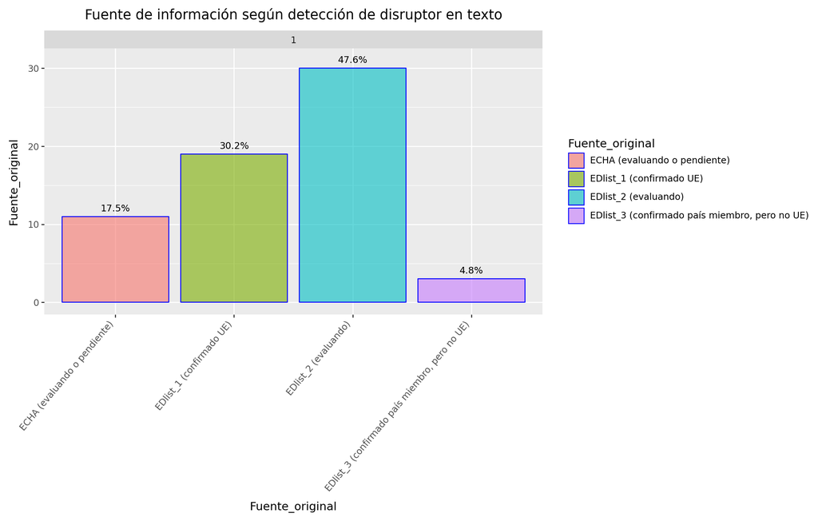

```python
# Gráfico de barras facetado por 'Fuente_original'
facet_bar_pct(df_enriquecido_text, xcol="Fuente_original", fill_col="Fuente_original", facet_col="acierto",
fig_width=11, fig_height=7, label_size=9,nudge_y=1,rotate=50,
title= "Fuente de información según detección de disruptor en texto")
```

El gráfico muestra la distribución de disruptores endocrinos identificados según la fuente de información `Fuente_original` en el análisis de texto.

- Predomina fuentes con disruptores no confirmados: **EDlist_2 (evaluando)** con un **47,6%** y **ECHA (evaluando o pendiente)** con un **17,5%**, lo que indica que casi **alrededor del 65%** de los ingredientes detectados corresponden a sustancias en proceso de evaluación, sin confirmación oficial aún como disruptores por la UE.
- El **35%** restantes se corresponde a disruptores confirmados: **EDlist_1 (confirmado UE)** y **EDlist_3 (confirmado por país miembro, pero no por la UE)** .

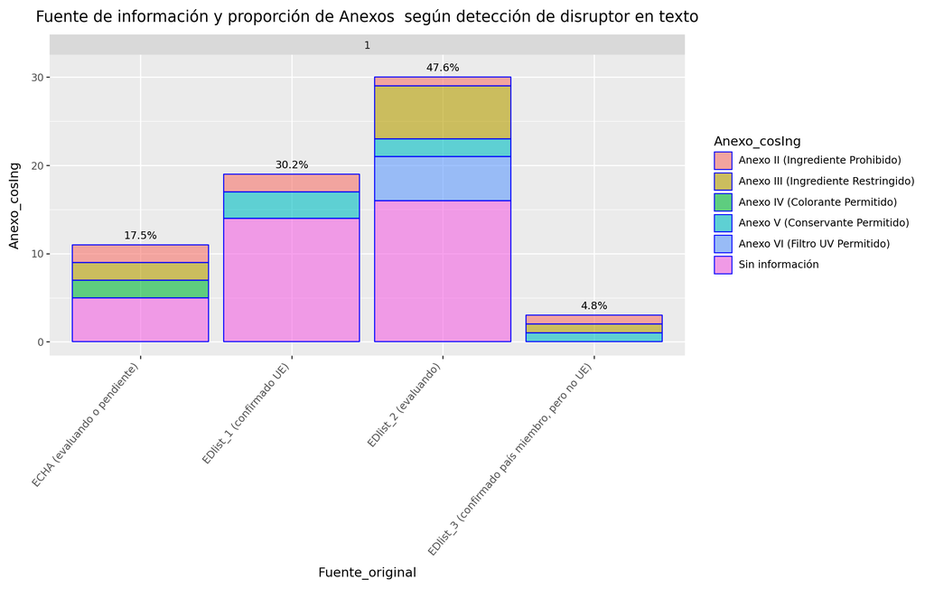

```python
# Gráfico de barras facetado por 'Fuente_original'
facet_bar_pct(df_enriquecido_text, xcol="Fuente_original", fill_col="Anexo_cosIng", facet_col="acierto",
fig_width=11, fig_height=7, label_size=9,nudge_y=1,rotate=50,
title= "Fuente de información y proporción de Anexos  según detección de disruptor en texto")
```

El gráfico muestra la relación entre la `Fuente_original` y la proporción de categorías de `Anexo_cosIng` según la detección de disruptores en texto.

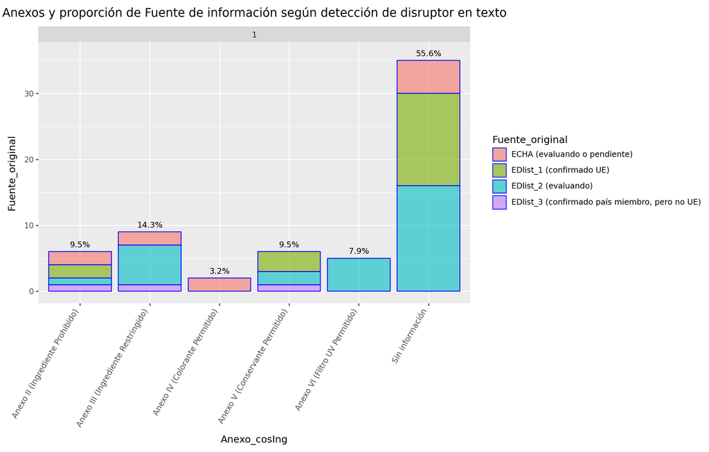

```python
# Gráfico de barras facetado por 'Anexo_cosIng'
facet_bar_pct(df_enriquecido_text, xcol="Anexo_cosIng", fill_col="Fuente_original", facet_col="acierto",
fig_width=11, fig_height=7, label_size=9,nudge_y=1,rotate=60,
title= "Anexos y proporción de Fuente de información según detección de disruptor en texto")
```

El gráfico muestra la relación entre los `Anexo_cosIng` y la `Fuente_original` según la detección de disruptores en texto.

- Predomina la categoría **sin información (55,6%)**, lo que refleja una gran falta de correspondencia entre sustancias detectadas y los anexos cosméticos.
- Destacan también los **Anexos III (14,3%)** y **II (9,5%)**, lo que evidencia que parte de las sustancias detectadas están **restringidas o prohibidas** en cosméticos.
- En menor medida aparecen sustancias en los **Anexos IV, V y VI **, lo que indica que algunos disruptores siguen teniendo usos autorizados bajo regulación específica, pero los Anexos IV y V contienen disruptores no confirmados.

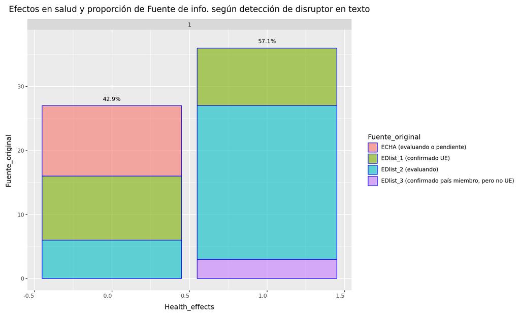

```python
# Gráfico de barras facetado por 'Health_effects'
facet_bar_pct(df_enriquecido_text, xcol="Health_effects", fill_col="Fuente_original", facet_col="acierto",
fig_width=11.5, fig_height=7, label_size=9,nudge_y=1,rotate=0,
title= "Efectos en salud y proporción de Fuente de info. según detección de disruptor en texto")
```

El gráfico muestra la relación entre los efectos en salud `Health_effects` y la `Fuente_original` según la detección de disruptores en texto.

### 6.2. Visualización de distribuciones en analisis de imágenes

```python
map = {
    1: "disruptor detectado",
    0: "disruptor NO detectado"
}
df_enriquecido_img["acierto"] = df_enriquecido_img["acierto"].replace(map)
```

```python
df_enriquecido_img["acierto"].value_counts()
```

```
acierto
disruptor detectado       165
disruptor NO detectado      5
Name: count, dtype: int64
```

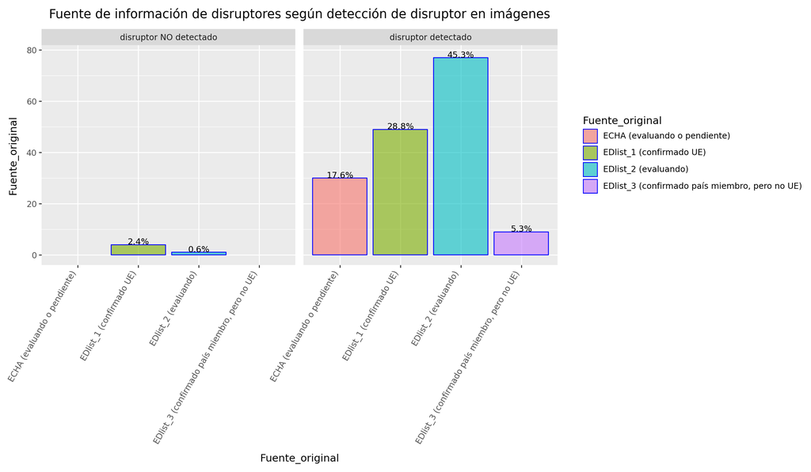

```python
# Gráfico de barras facetado por 'Fuente_original'
facet_bar_pct(df_enriquecido_img, xcol="Fuente_original", fill_col="Fuente_original", facet_col="acierto",
fig_width=12, fig_height=7, label_size=9,nudge_y=1,rotate=60,
title= "Fuente de información de disruptores según detección de disruptor en imágenes")
```

El gráfico muestra la relación entre la `Fuente_original` y la detección de disruptores en imágenes.

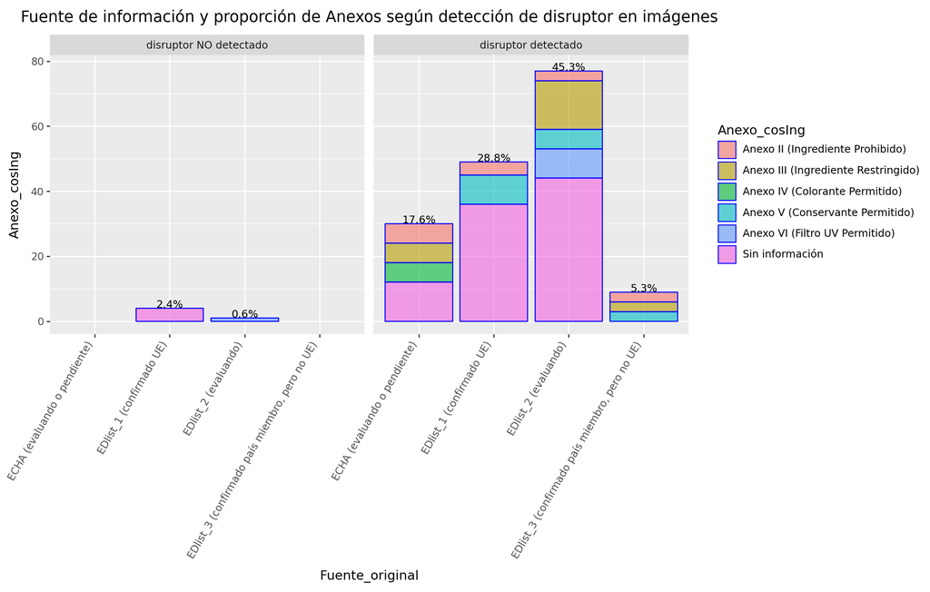

```python
# Gráfico de barras facetado por 'Fuente_original'
facet_bar_pct(df_enriquecido_img, xcol="Fuente_original", fill_col="Anexo_cosIng", facet_col="acierto",
fig_width=11, fig_height=7, label_size=9,nudge_y=1,rotate=60,
title= "Fuente de información y proporción de Anexos según detección de disruptor en imágenes")
```

El gráfico muestra la relación entre la `Fuente_original` y los `Anexo_cosIng` según la detección de disruptores en imágenes.

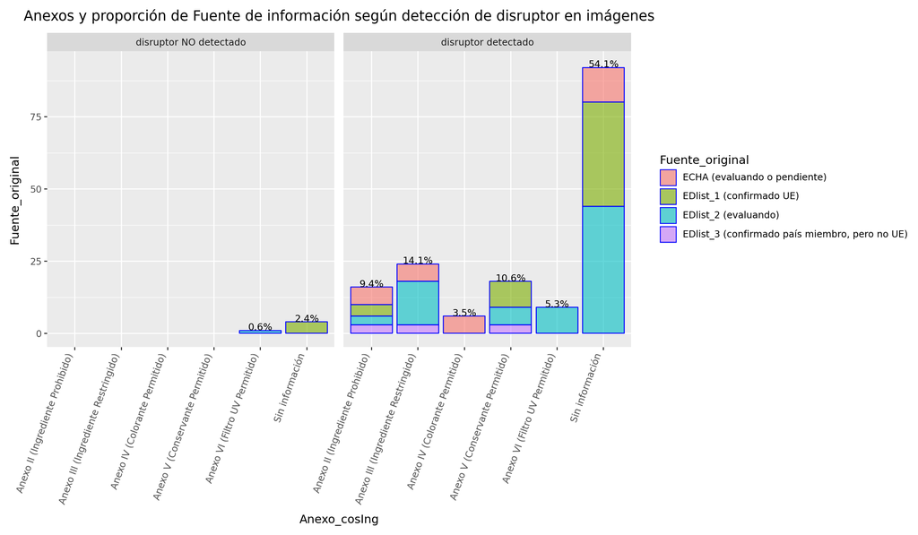

```python
# Gráfico de barras facetado por 'Anexo_cosIng'
facet_bar_pct(df_enriquecido_img, xcol="Anexo_cosIng", fill_col="Fuente_original", facet_col="acierto",
fig_width=12, fig_height=7, label_size=9,nudge_y=1,rotate=70,
title= "Anexos y proporción de Fuente de información según detección de disruptor en imágenes")
```

- Predomina la categoría **sin información (54,1%)**, lo que refleja una gran falta de correspondencia entre sustancias detectadas y los anexos cosméticos.
- Destacan también los **Anexos III (14,1%)** y **II (9,4%)**, lo que evidencia que parte de las sustancias detectadas están **restringidas o prohibidas** en cosméticos.
- En menor medida aparecen sustancias en los **Anexos IV, V y VI **, lo que indica que algunos disruptores siguen teniendo usos autorizados bajo regulación específica, pero los Anexos IV y V contienen disruptores no confirmados.
- En el grupo **disruptor no detectado**, los porcentajes son bajos y se concentran en la categoría de **sin información**, lo que refleja pérdida de trazabilidad regulatoria. Perdemos algo de información del **Anexo VI**

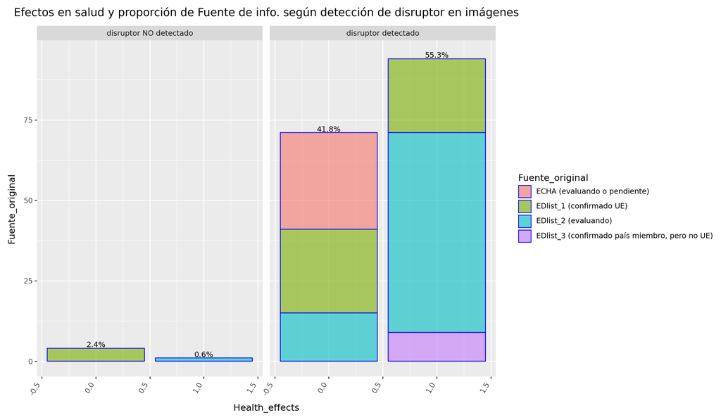

```python
# Gráfico de barras facetado por 'Health_effects'
facet_bar_pct(df_enriquecido_img, xcol="Health_effects", fill_col="Fuente_original", facet_col="acierto",
fig_width=12, fig_height=7, label_size=9,nudge_y=1,rotate=60,
title= "Efectos en salud y proporción de Fuente de info. según detección de disruptor en imágenes")
```